# Red Wine Quality Exploration by Mahmoud Esmail

> **Dataset Introduction**: We are going to find correlations between the 11 features in RedWine dataset and after analyzing it. we will find factors that affects wine quality

```
##        X          fixed.acidity   volatile.acidity  citric.acid
##  Min.   :   1.0   Min.   : 4.60   Min.   :0.1200   Min.   :0.000
##  1st Qu.: 400.5   1st Qu.: 7.10   1st Qu.:0.3900   1st Qu.:0.090
##  Median : 800.0   Median : 7.90   Median :0.5200   Median :0.260
##  Mean   : 800.0   Mean   : 8.32   Mean   :0.5278   Mean   :0.271
##  3rd Qu.:1199.5   3rd Qu.: 9.20   3rd Qu.:0.6400   3rd Qu.:0.420
##  Max.   :1599.0   Max.   :15.90   Max.   :1.5800   Max.   :1.000
##  residual.sugar     chlorides       free.sulfur.dioxide
##  Min.   : 0.900   Min.   :0.01200   Min.   : 1.00
##  1st Qu.: 1.900   1st Qu.:0.07000   1st Qu.: 7.00
##  Median : 2.200   Median :0.07900   Median :14.00
##  Mean   : 2.539   Mean   :0.08747   Mean   :15.87
##  3rd Qu.: 2.600   3rd Qu.:0.09000   3rd Qu.:21.00
##  Max.   :15.500   Max.   :0.61100   Max.   :72.00
##  total.sulfur.dioxide    density             pH          sulphates
##  Min.   :  6.00       Min.   :0.9901   Min.   :2.740   Min.   :0.3300
##  1st Qu.: 22.00       1st Qu.:0.9956   1st Qu.:3.210   1st Qu.:0.5500
##  Median : 38.00       Median :0.9968   Median :3.310   Median :0.6200
##  Mean   : 46.47       Mean   :0.9967   Mean   :3.311   Mean   :0.6581
##  3rd Qu.: 62.00       3rd Qu.:0.9978   3rd Qu.:3.400   3rd Qu.:0.7300
##  Max.   :289.00       Max.   :1.0037   Max.   :4.010   Max.   :2.0000
##     alcohol         quality
##  Min.   : 8.40   Min.   :3.000
##  1st Qu.: 9.50   1st Qu.:5.000
##  Median :10.20   Median :6.000
##  Mean   :10.42   Mean   :5.636
##  3rd Qu.:11.10   3rd Qu.:6.000
##  Max.   :14.90   Max.   :8.000
```

```
## 'data.frame':    1599 obs. of  13 variables:
##  $ X                   : int  1 2 3 4 5 6 7 8 9 10 ...
##  $ fixed.acidity       : num  7.4 7.8 7.8 11.2 7.4 7.4 7.9 7.3 7.8 7.5 ...
##  $ volatile.acidity    : num  0.7 0.88 0.76 0.28 0.7 0.66 0.6 0.65 0.58 0.5 ...
##  $ citric.acid         : num  0 0 0.04 0.56 0 0 0.06 0 0.02 0.36 ...
##  $ residual.sugar      : num  1.9 2.6 2.3 1.9 1.9 1.8 1.6 1.2 2 6.1 ...
##  $ chlorides           : num  0.076 0.098 0.092 0.075 0.076 0.075 0.069 0.065 0.073 0.071 ...
##  $ free.sulfur.dioxide : num  11 25 15 17 11 13 15 15 9 17 ...
##  $ total.sulfur.dioxide: num  34 67 54 60 34 40 59 21 18 102 ...
##  $ density             : num  0.998 0.997 0.997 0.998 0.998 ...
##  $ pH                  : num  3.51 3.2 3.26 3.16 3.51 3.51 3.3 3.39 3.36 3.35 ...
##  $ sulphates           : num  0.56 0.68 0.65 0.58 0.56 0.56 0.46 0.47 0.57 0.8 ...
##  $ alcohol             : num  9.4 9.8 9.8 9.8 9.4 9.4 9.4 10 9.5 10.5 ...
##  $ quality             : int  5 5 5 6 5 5 5 7 7 5 ...
```

**Summary of the dataset**:

- we have 1599 object and 12 variable at which 11 of them are features that describes quality of wine
- it turns out that the max quality of wine reaches 8.0 and no quality is higher than that, while the average quality is 5.635

# Univariate Plots Section

- in this section I’m going to examine the distribution-
- of each variable in this dataset by plots to check whether it’s normally distributed or not

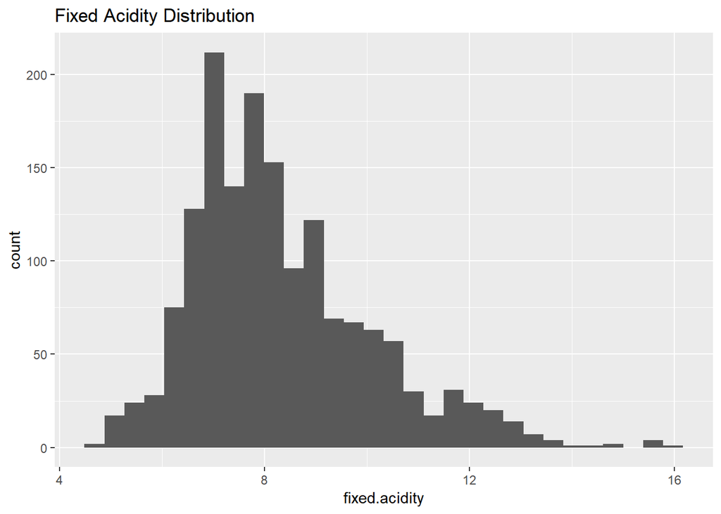

**Observations**

- fixed acidity distribution is long tailed we need to fix it

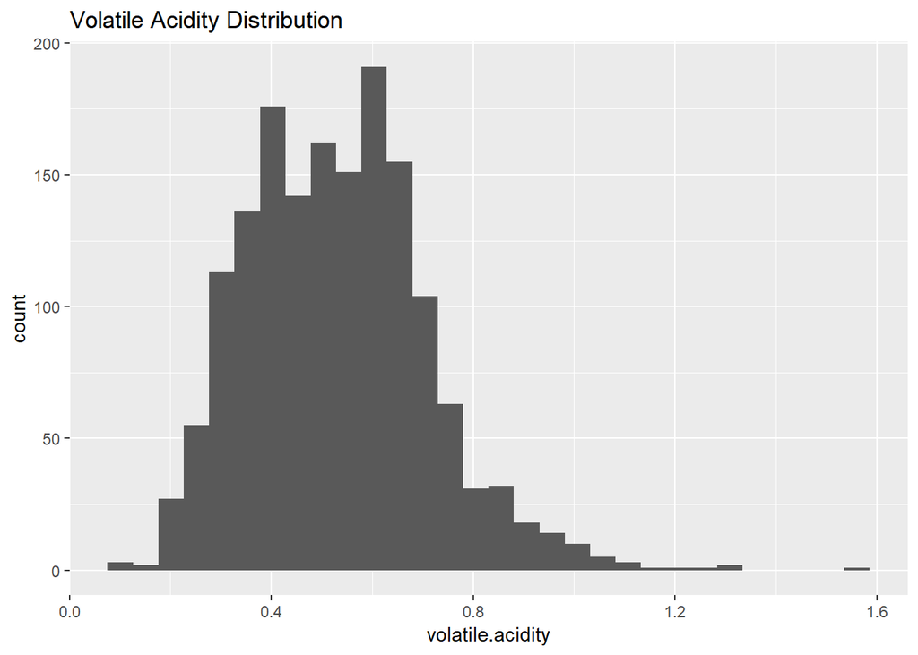

**Observations**

- volatile acidity distribution is long tailed we need to fix it

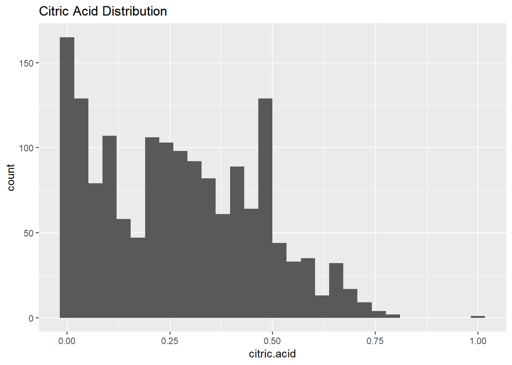

**Observations**

- citric acid distribution is positively skewed

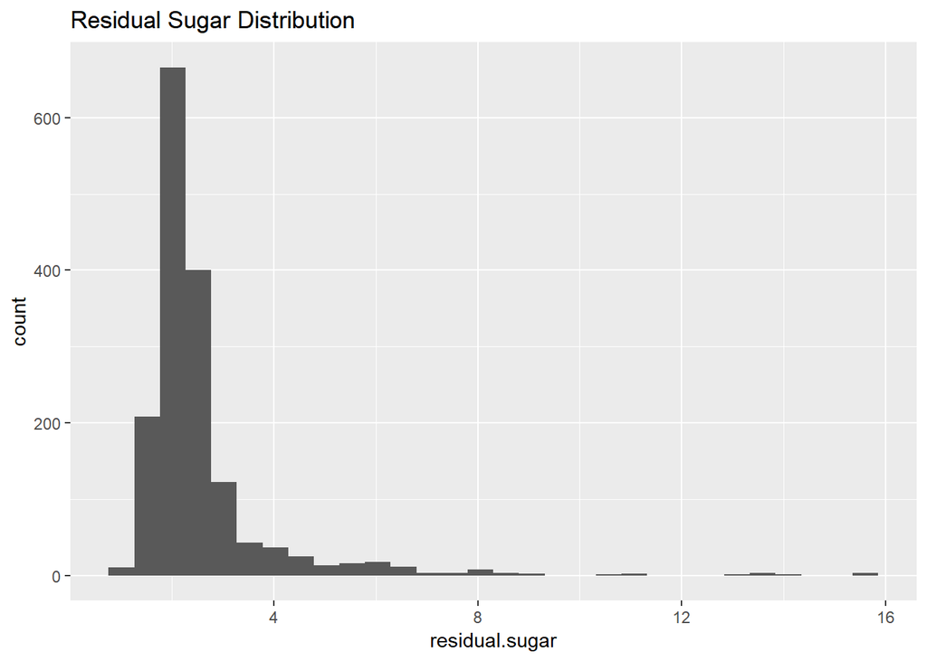

**Observations**

- residual sugar is not normally distributed, it’s long tailed,  
  starting from non-zero position and there’s  
  a few outliers at values after 5 on the scale

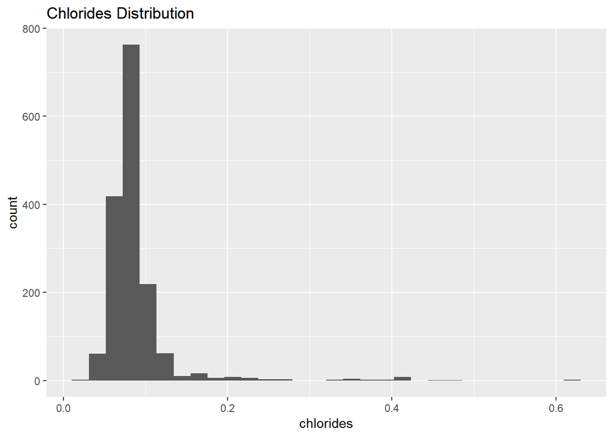

**Observations**

- chlorides is long tailed disrtibution, there’s a few outliers from 0.4 to 0.6

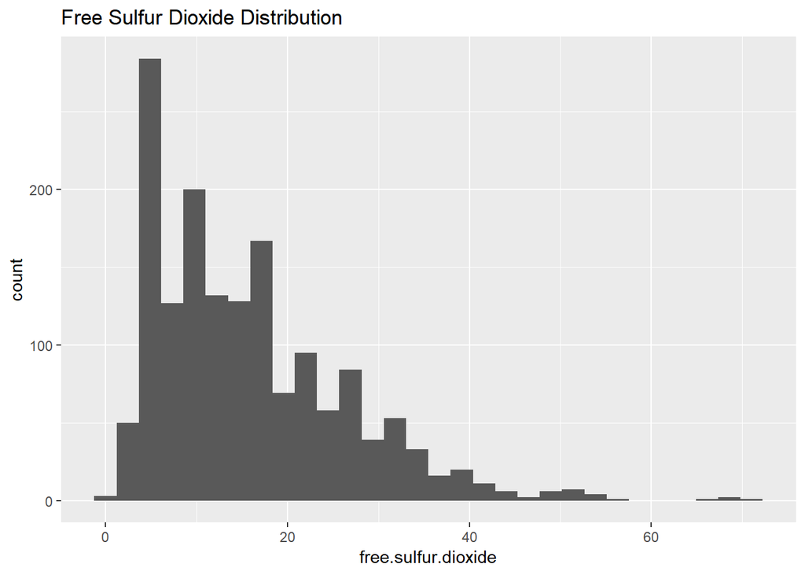

**Observations**

- free sulphur dioxide distribution is long tailed

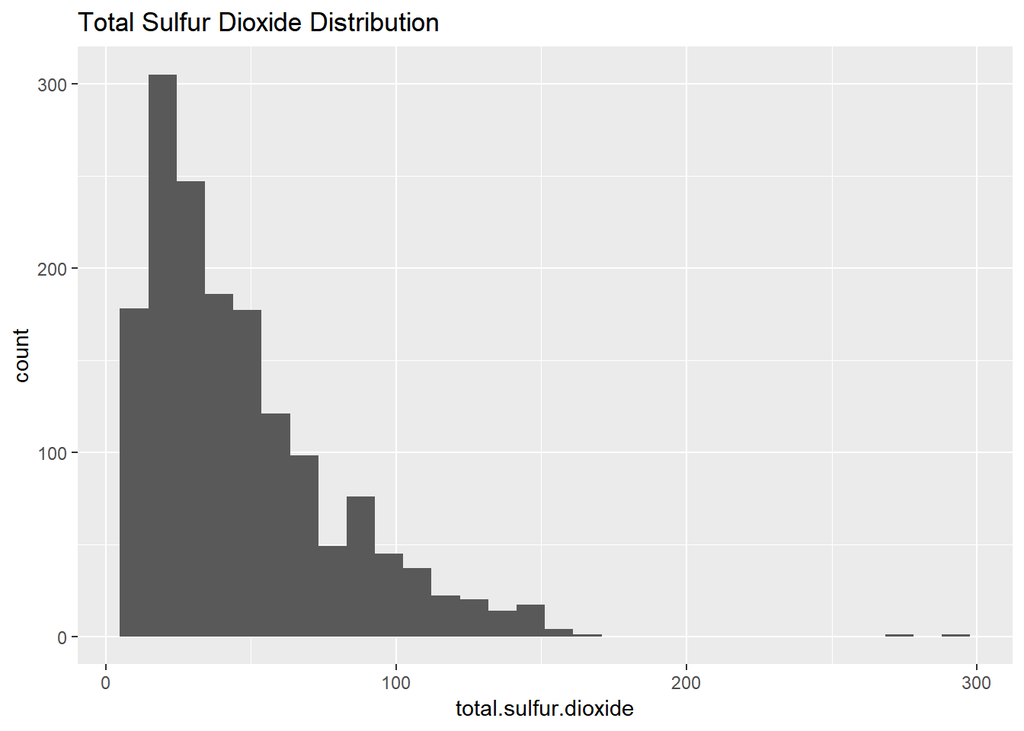

**Observations**

- total sulphure dioxide is long tailed distribution it need to be added on  
  log10 scale to see if it could be normally distributed

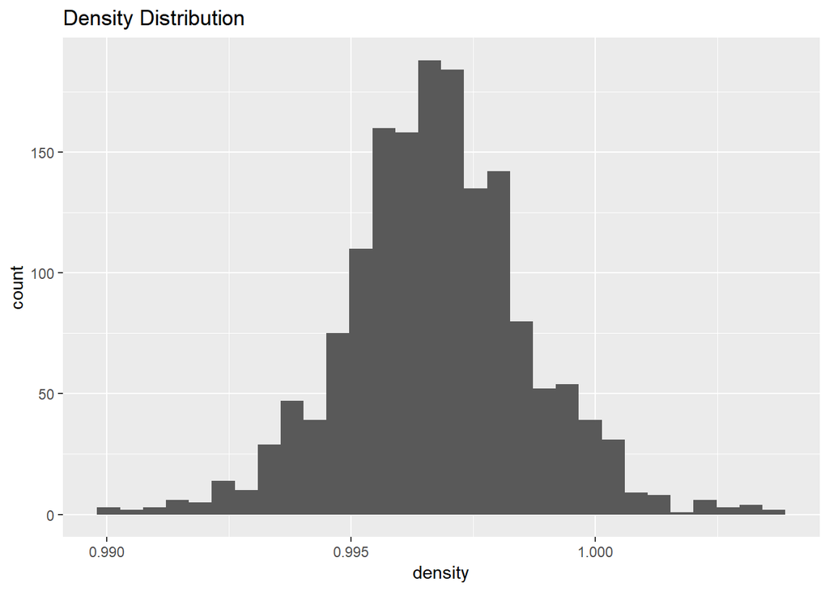

**Observations**

- when we take a look density plot we realize that it’s normally distributed

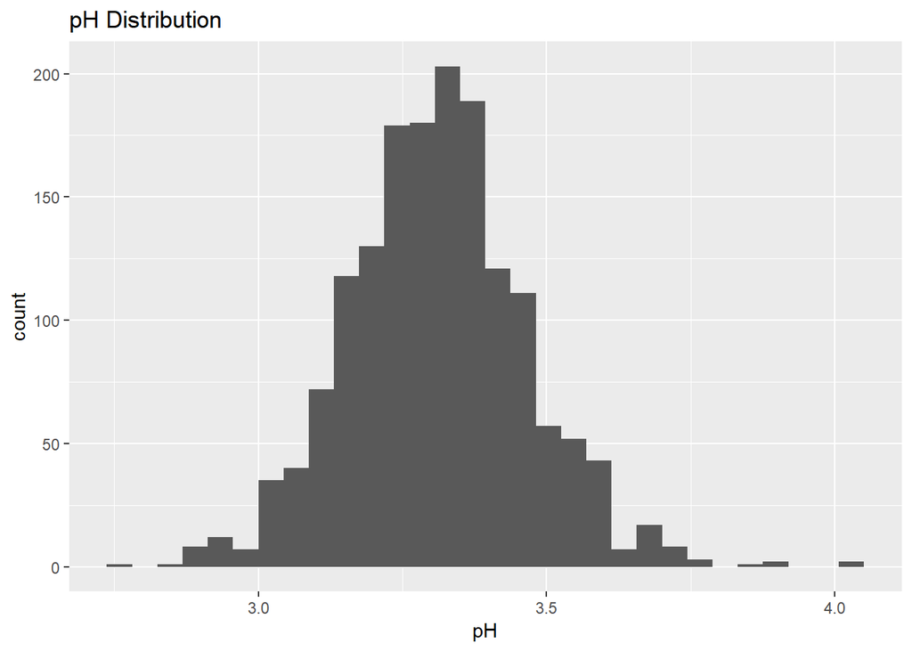

**Observations**

- when we take a look pH plot we realize that it’s normally distributed

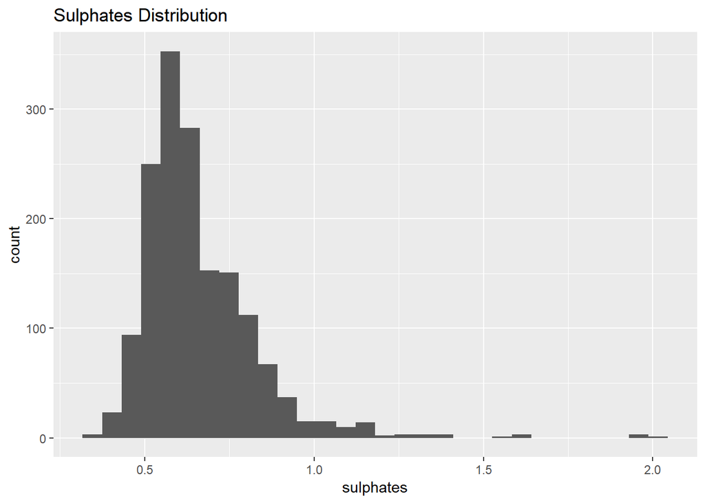

**Observations**

- sulphates distribution is long-tailed

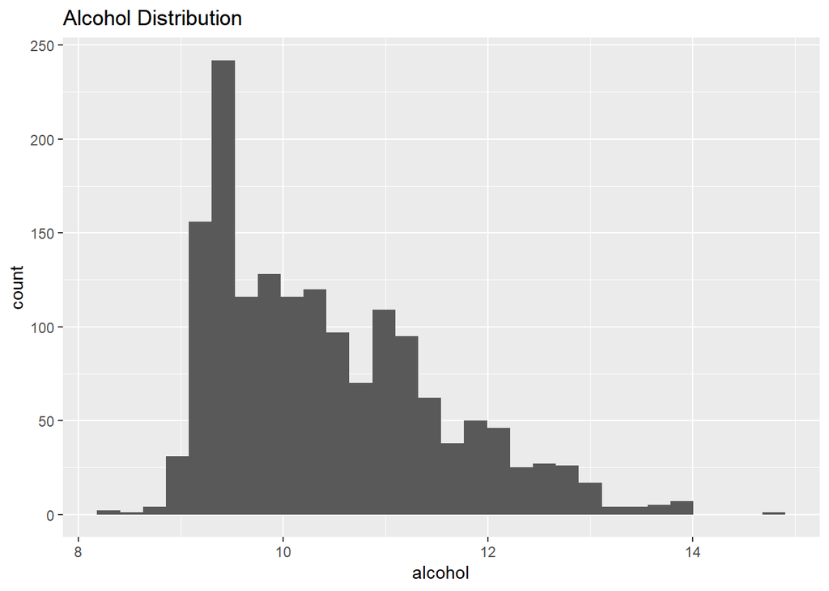

**Observations**

- there’s a few outliers before 9 and after the 14
- the histogram could be divided into two plots before and after 11 on the scale, after dividing it  
  we see that the two plots are not normally distributed

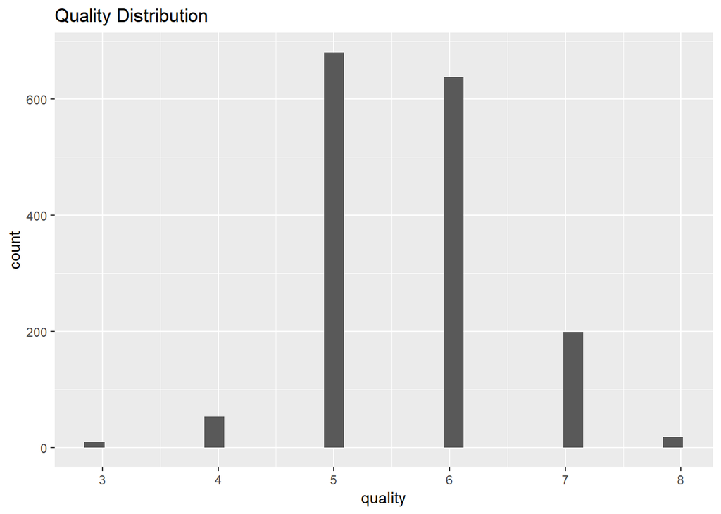

**Observations**

- most of wine qualities are between 5 and 6 on average, where lowest quality  
  is nearly about 3 and highest quality is nearly 8

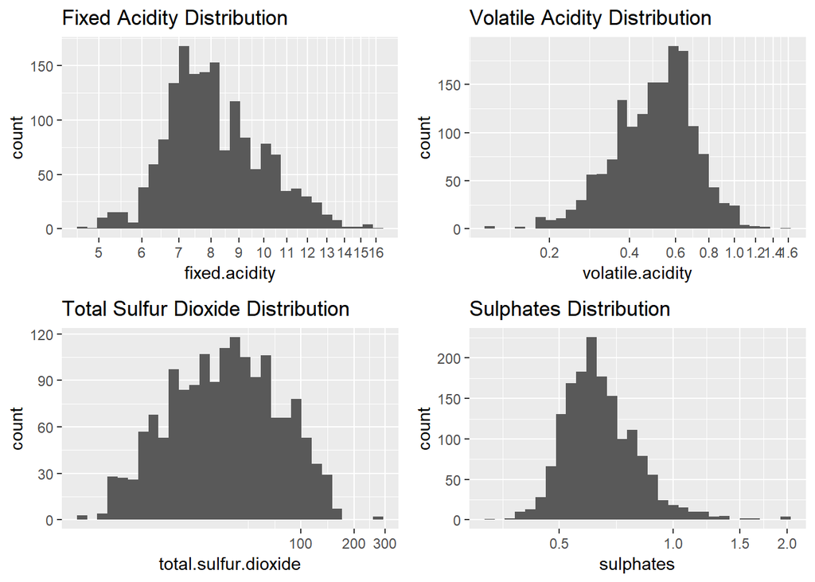

**Observations**

- Now the plots became more normally distributed, but still there’s a small outliers

# Univariate Analysis

### What is the structure of your dataset?

- the dataset contains 12 main variables or objects each of which describes the quality of red wine
- Actually, the 12 variables 11 of them are experimental variables or

  in other words they’re measurements to describe the attributes of wine

  while the one left variable which is “quality” is a variable which is

  rated from 0 to 10 by wine experts
- the worst wine is rated nearly 3 while the best is about 8

### What is/are the main feature(s) of interest in your dataset?

the main feature in our dataset is Quality of the red wine

### What other features in the dataset do you think will help support your

investigation into your feature(s) of interest?

most of variables(features) in the dataset could support the investigation but the most powerful features

that may support the investigation are pH, Alcohol and residual sugar

### Did you create any new variables from existing variables in the dataset?

No

### Of the features you investigated, were there any unusual distributions?

Did you perform any operations on the data to tidy, adjust, or change the form of the data? If so, why did you do this?

- I performed adjustments on the distributions that doesn’t seem to be normal

(fixed.acidity, volatile.acidity, total sulphur dioxide, sulphates),  
I did so to see if they could be normally distributed to find the mean value

of the attribute and whether or not it has huge impact on the quality of red wine

- the unusual distribution appears on quality distribution because there’s a few values in 3, 4, 8 while  
  the most of values ranges

between 5 and 6 which means there’s a roam for unstability though.

# Bivariate Plots Section

**In this Plotting Section**: I’m going to plot every single attribute against quality to see if there’s a correlation between the variables

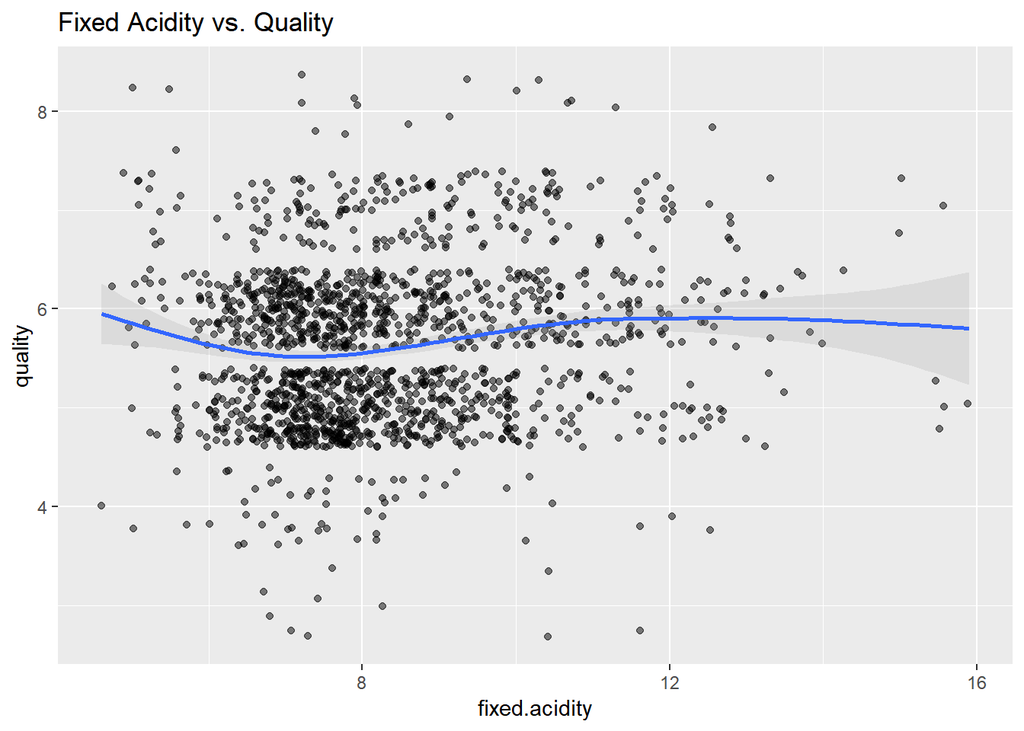

**Observation**:

- There’s no correlation between fixed acidity and quality

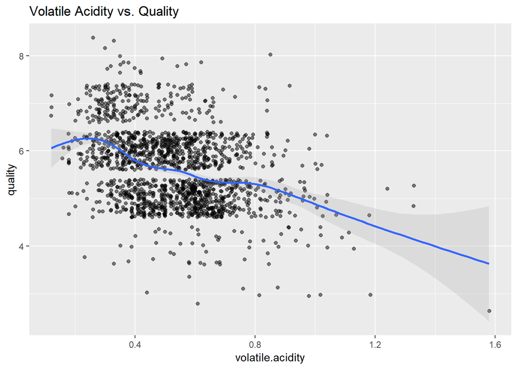

**Observation**:

- At some regions there’s no correlation between volatile acidity and quality and at another points  
  there’s a weak correlation at which the higher volatile acidity the lower quality

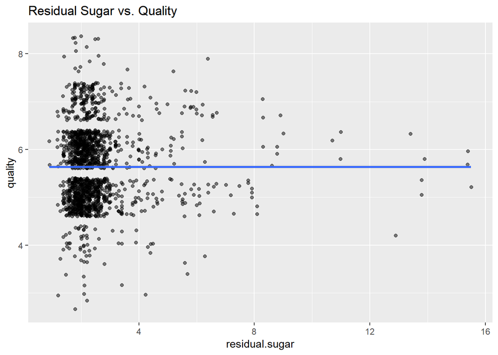

**Observation**:

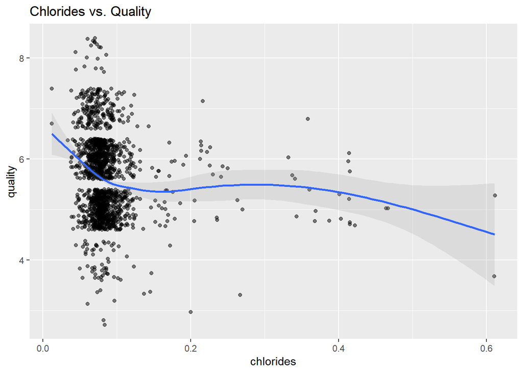

**Observation**:

- The lower the chlorides the higher the quality

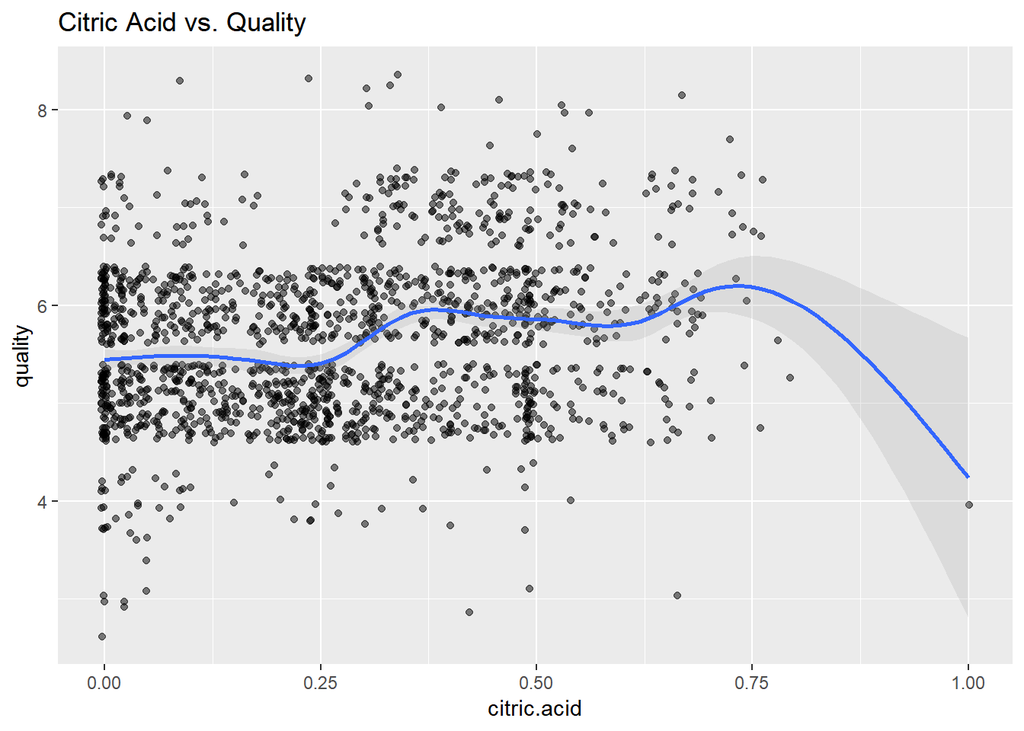

**Observation**:

- There’s no clear correlation between citric acid and quality

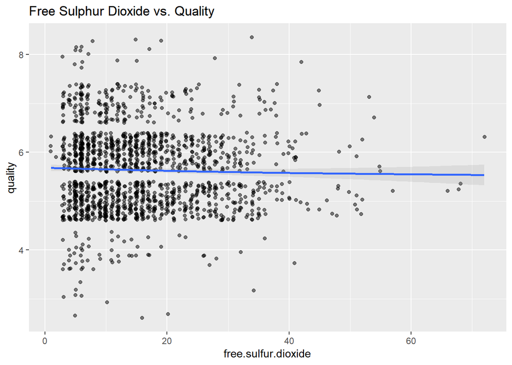

**Observation**:

- There’s no correlation between free sulphur dioxide and quality

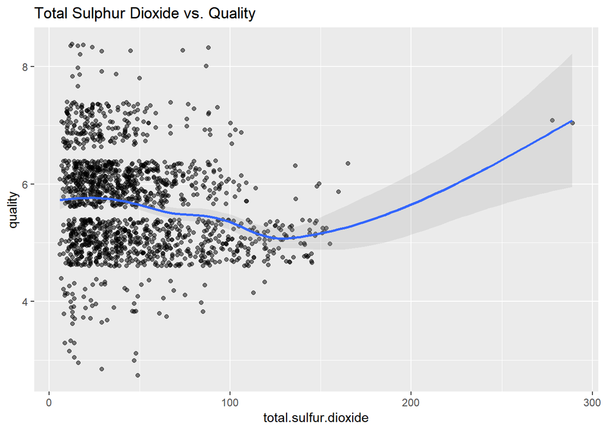

**Observation**

- there’s no clear correlation between total sulphur dioxide and quality

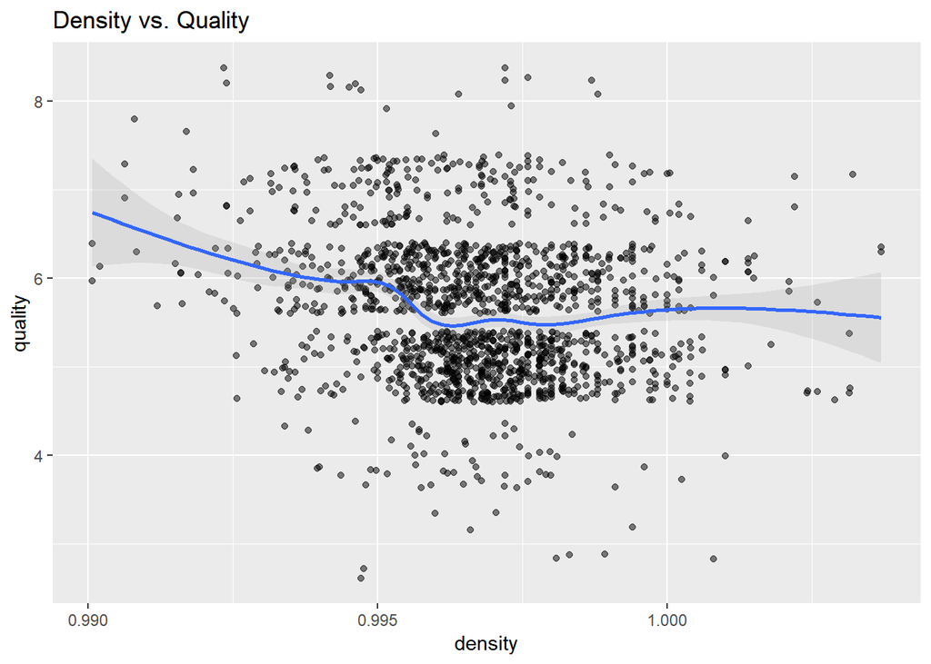

**Observation**:

- There’s no correlation between density and quality

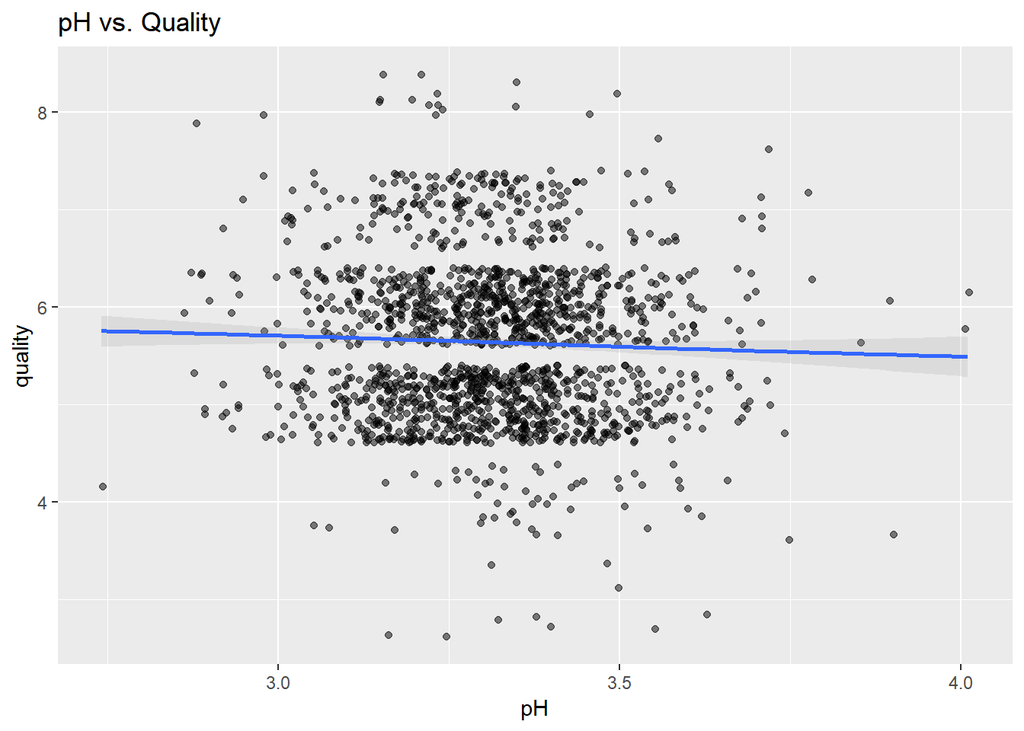

**Observation**:

- There’s no strong correlation between pH and quality

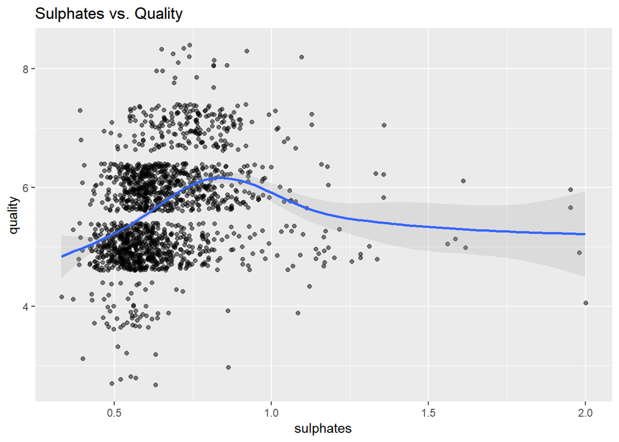

**Observation**:

- There’s no strong correlation between sulphates and quality at some points below 0.7  
  the higher sulphates means higher quality after that point,  
  I see the higher sulphates means lower quality

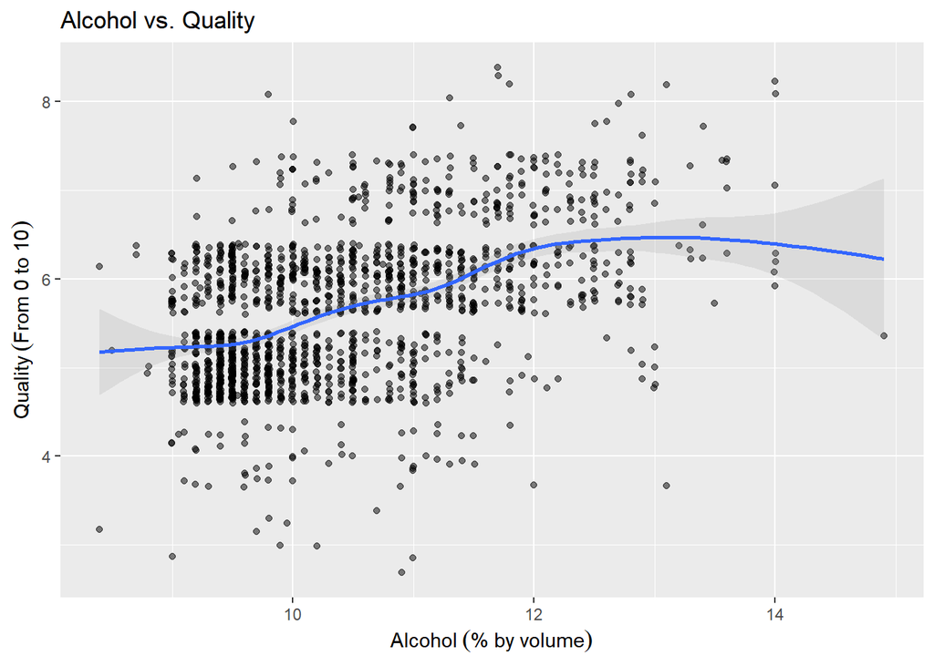

**Observation**:

- at some points it appears there’s a small correlation which implies that the the higher the quality  
  the higher the alcohol quantity

## Also I’m Going to plot some relations between input variables to see

Correlations

[figure not shown]

**Observations**

- total sulphur and free sulphur dioxide has a strong correlation
- fixed acidity and citric acid has strong correlation

# Bivariate Analysis

### Talk about some of the relationships you observed in this part of the

investigation. How did the feature(s) of interest vary with other features in the dataset?

### Did you observe any interesting relationships between the other features

(not the main feature(s) of interest)?

- Fixed acidity and citric acid are correlated in a positive way
- total sulphur dioxides are strongly correlated with free sulphur dioxides

### What was the strongest relationship you found?

# Multivariate Plots Section

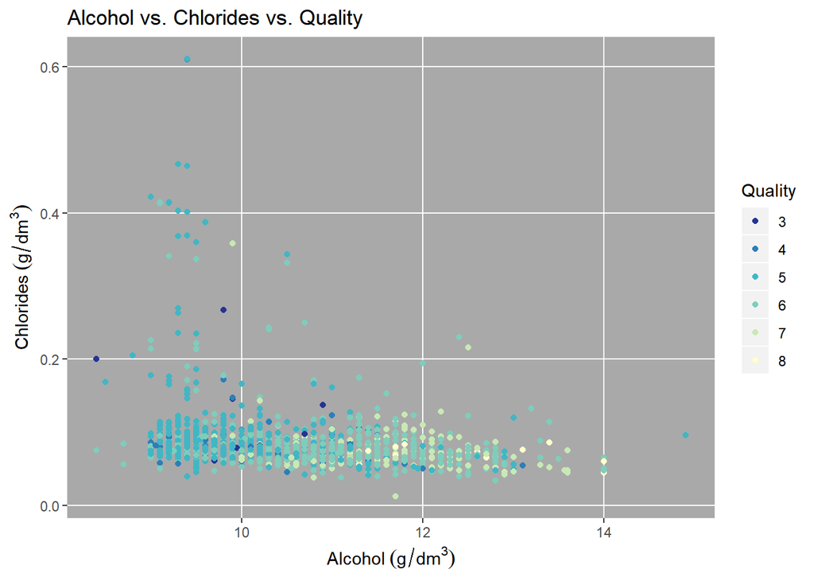

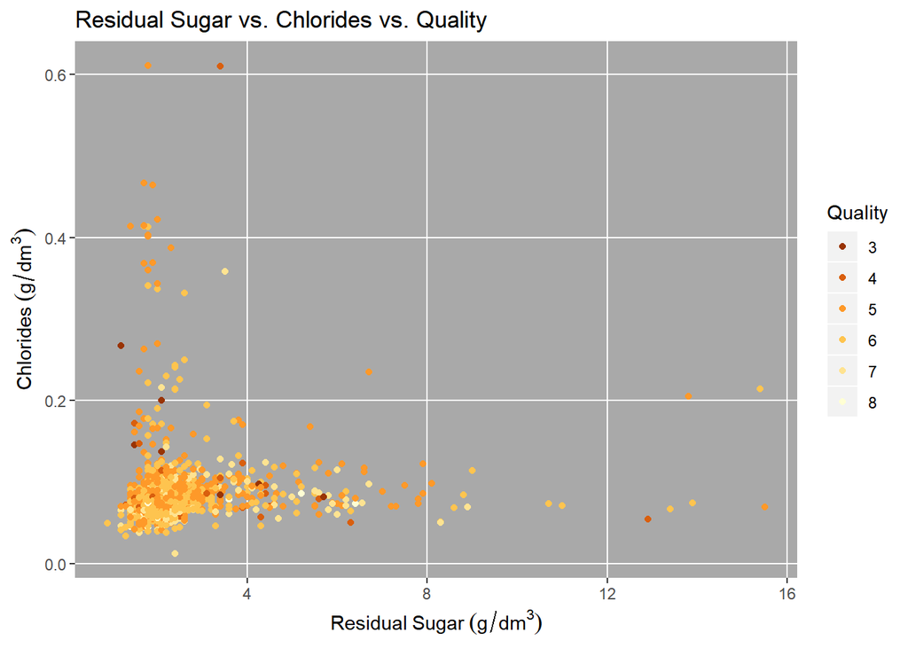

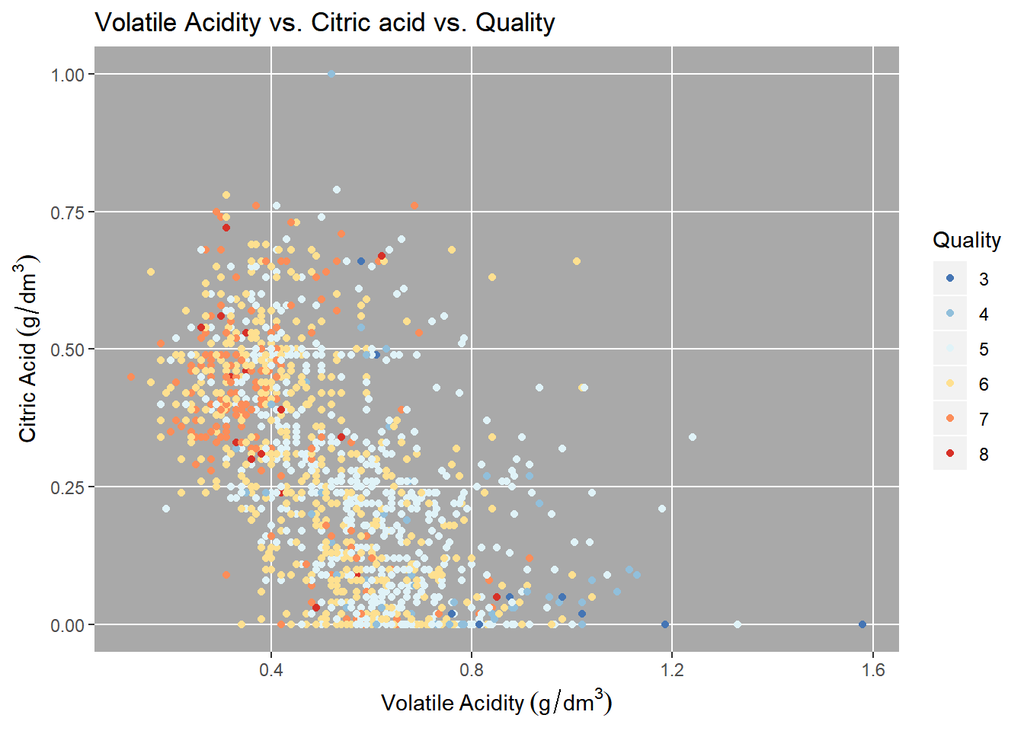

# Multivariate Analysis

### Talk about some of the relationships you observed in this part of the

investigation. Were there features that strengthened each other in terms of looking at your feature(s) of interest?

- when we putted down alcohol vs chlorides vs quality in a plot it looks like it strenghten the insights and it makes it  
  comfortable to say that the higher alcohol with smaller amount of chlorides  
  makes the best quality rating
- there’s no strong correlations of residual sugar with chlorides there’s some points when  
  the amount sugar increase above the limit  
  and amount of chloride is few the quality decreases
- when the volatile acidity is low with a high citric acid the quality becomes high, and vice versa.

### Were there any interesting or surprising interactions between features?

# Final Plots and Summary

### Plot One

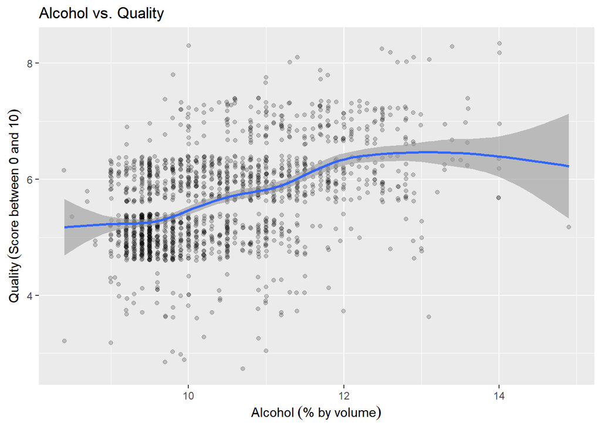

### Description One

- alcohol affects the quality rating of the redwine, it’s not the only factor that affects but  
  it’s the most powerful attribute that affects the final rating

### Plot Two

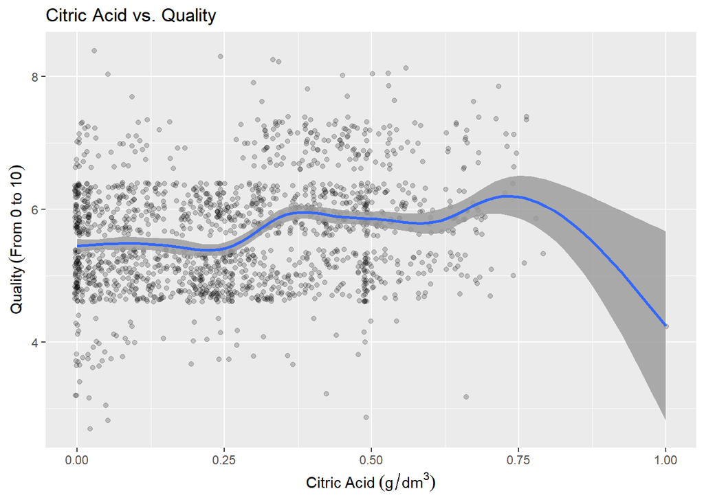

### Description Two

- citric acid seems to be a little bit effective on the quality even if the plot doesn’t  
  give a strong a correlation  
  but one thing i noticed is that smooth wave that goes up at 0.25 this inferes that the quality  
  might increase by increasing  
  the amount of citric acid but it not might be the only factor  
  of increasing quality as there’s another factors

### Plot Three

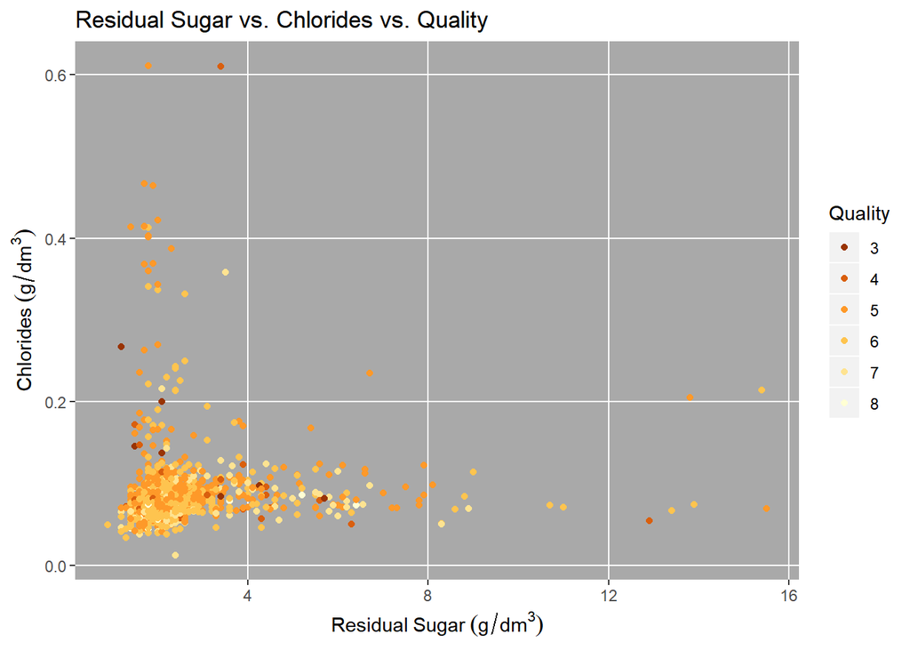

### Description Three

# Reflection